# Wolframite demo

This notebook demonstrates basic usage of [Wolframite](https://github.com/scicloj/wolframite/) in a way that would work in visual tools supporting [Kindly](https://scicloj.github.io/kindly-noted/kindly).

```
(ns demo
  (:require
   [wolframite.core :as wl]
   [wolframite.wolfram :as w]
   [wolframite.impl.jlink-instance :as jlink-instance]
   [wolframite.tools.hiccup :refer [view]]
   [wolframite.base.parse :as parse]
   [scicloj.kindly.v4.kind :as k])
  ;; (:import (java.awt Color Frame)
  ;;          (java.awt.event WindowAdapter ActionEvent))
  )
```

# Quickstart

A brief demonstration of what Wolframite can do. It's a quick read, but you can also jump to any section of interest.

## Init

First, we must initialize Wolframite and connect it to a Wolfram kernel, which will perform the computations.

```
(wl/start)
```

If you get an error then please refer to the home README for further instructions. Your Wolfram installation is probably just in an unusual place and so you will have to provide the correct path.

## First things first

To check that the kernel is working, try the following command:

```
(wl/eval '(Dot [1 2 3] [4 5 6]))
```

```
32
```

As you can see, we can treat Wolfram commands similarly to unevaluated Clojure source code, with some predictable syntax adaptations. This works fine as a starting point, but dealing with long chains of raw symbols doesn't always scale well. Instead, you can also write

```
(wl/eval (w/Dot [1 2 3] [4 5 6]))
```

```
32
```

or, using one of our fancy aliases,

```
(wl/eval (w/<*> [1 2 3] [4 5 6]))
```

```
32
```

, which may be more familiar to the Mathematically inclined.

Here, the 'w' namespace is a preconfigured, but configurable, intermediary to Wolfram's built-in symbols. This allows you to manipulate Wolfram functions just like any other clojure symbol (and get reliable editor autocompletion).

## Code strings

The above examples are the preferred ways to interop. You can however, use Wolfram command strings directly, e.g.

```
(wl/eval "{1 , 2, 3} . {4, 5, 6}")
```

```
32
```

## Explicit interning

Although it shouldn't normally be necessary, we can also intern Wolfram functions more directly i.e. to effectively define Wolfram functions as clojure functions.

The standard way of doing this is something like

```
(def greetings
  (wl/eval
   (w/fn [x] (w/StringJoin "Hello, " x "! This is a Mathematica function's output."))))
```

```
(greetings "Stephen")
```

```
"Hello, Stephen! This is a Mathematica function's output."
```

But this can also be done at a lower level, e.g.

```
(def W:Plus
  (parse/parse-fn 'Plus {:jlink-instance (wolframite.impl.jlink-instance/get)}))
```

```
(W:Plus 1 2 3)
```

```
6
```

## Bidirectional translation (experimental)

Code translation in both directions is more difficult and is still somewhat experimental (especially in the wl->clj direction), but the basics work as expected, e.g.

```
(wl/->clj "GridGraph[{5, 5}]")
```

```
(GridGraph [5 5])
```

```
(wl/->wl (w/GridGraph [5 5]) {:output-fn str})
```

```
"GridGraph[{5, 5}]"
```

## Graphics

The above code however, within Mathematica, actually produces graphics. Does Wolframite support this?

Yes!

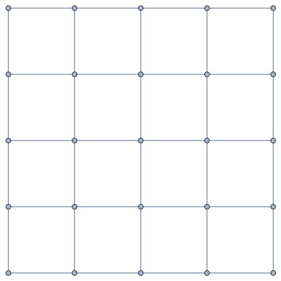

[figure not shown]

The above graphics were created using the

```
view
```

function, as required above, and assumes that graphics are to be displayed in a browser.

## Computational knowledge

Wolfram is also known for its dynamic or 'computational knowledge' engine.

```
(wl/eval (w/WolframAlpha "number of moons of Saturn" "Result"))
```

```
(Quantity 145 (IndependentUnit "moons"))
```

## Mathematics and beyond

In a nutshell, this is how Wolframite is normally used, but, of course, this barely scratches the surface.

This is where Wolfram, and so Wolframite, really shines. And if you're interested in exploring this further, have a gander at one of our longer tutorials.

```
source: notebooks/demo.clj
```